# Discussion Section Worksheet #6

Anupama Bhatta

October 31, 2023

# Learning objectives

- Practice sampling a dataset
- Understand the relationship between a dataset, a sample statistic, and a population statistic
- Understand which factors contribute to sample variability
- Visualize a sample distribution

## Recap from lecture

In last week's lecture, we learned about **sampling** - randomly selecting only a few members of a population to study. If sampling is done properly, we can make an **inference** (meaning, we can *learn something*) about the population as a whole. We used a toy example where the population was a bowl full of red and white balls, and we sampled by mixing up the bowl and taking a scoop.

In each scoop, we could calculate a statistic (what proportion of balls were red). Because the balls in each scoop had been randomly sampled, we had some confidence that the **sample statistic** (what proportion of balls were red in a single scoop) was not far off from the **population statistic** (what proportion of balls were red in the whole bowl).

We also saw that our sample statistic can vary across samples (scoops). Sometimes, just by chance, you get a lot of red. Other times, you don't. This is called **sampling variability**.

### The relationship between sampling variability and confidence

In order to make a confident inference (meaning, learning about the population) from a sample, we have to know how much sampling variability exists: - If your sample statistic varies drastically from sample to sample, you shouldn't be very confident making inferences about the whole population from any one sample. - If your sample statistic is consistent from sample to sample (it doesn't change very much), you can be much more confident in your inference about the whole population.

## Let's practice

There are a lot of new terms and concepts here, so let's keep practicing with them. We'll use the `alaska_flights` dataframe that is part of `moderndive` to get at an inferential question: *what's the typical flight delay for an Alaska Airlines flight?*

```r
set.seed(2)
library(moderndive)
library(ggplot2)
library(dplyr)
library(infer) # this is a new library from last lecture!

alaska_flights <- alaska_flights %>%
  na.omit
```

## Sample the dataframe

Similar to how we "scooped" a limited number of balls from the bowl, let's simulate what would happen if we picked 50 random flights to study.

```r
sample_alaska_flights <- alaska_flights %>%
  rep_sample_n(size = 50)
sample_alaska_flights
```

```
## # A tibble: 50 × 20
## # Groups:   replicate [1]
##    replicate  year month   day dep_time sched_…¹ dep_d…² arr_t…³ sched…⁴ arr_d…⁵
##        <int> <int> <int> <int>    <int>    <int>   <dbl>   <int>   <int>   <dbl>
##  1         1  2013     5     5     1834     1820      14    2106    2133     -27
##  2         1  2013     4    23     2104     1820     164      12    2131     161
##  3         1  2013     2    23      713      725     -12    1001    1030     -29
##  4         1  2013     4     2      719      725      -6    1007    1030     -23
##  5         1  2013    12    17     1918     1825      53    2253    2152      61
##  6         1  2013     4    18      834      725      69    1141    1015      86
##  7         1  2013     3     7      714      725     -11    1047    1030      17
##  8         1  2013     9    21      714      720      -6     945    1025     -40
##  9         1  2013     7    31     1835     1825      10    2201    2147      14
## 10         1  2013     8    28     1839     1835       4    2141    2158     -17
## # … with 40 more rows, 10 more variables: carrier <chr>, flight <int>,
## #   tailnum <chr>, origin <chr>, dest <chr>, air_time <dbl>, distance <dbl>,
## #   hour <dbl>, minute <dbl>, time_hour <dttm>, and abbreviated variable names
## #   ¹sched_dep_time, ²dep_delay, ³arr_time, ⁴sched_arr_time, ⁵arr_delay
## # ℹ Use `print(n = ...)` to see more rows, and `colnames()` to see all variable names
```

What's the average flight delay in this sample?

```r
summary_mean_one <- sample_alaska_flights %>%
  summarize(mean = mean(dep_delay))
summary_mean_one
```

```
## # A tibble: 1 × 2
##   replicate  mean
##       <int> <dbl>
## 1         1  4.58
```

## Sample the dataframe again

Now, repeat what you did. Once again get a sample....

```r
sample_alaska_flights_two <- alaska_flights %>%
  rep_sample_n(size = 50)
sample_alaska_flights_two
```

```
## # A tibble: 50 × 20
## # Groups:   replicate [1]
##    replicate  year month   day dep_time sched_…¹ dep_d…² arr_t…³ sched…⁴ arr_d…⁵
##        <int> <int> <int> <int>    <int>    <int>   <dbl>   <int>   <int>   <dbl>
##  1         1  2013     9    10      717      720      -3     941    1025     -44
##  2         1  2013     5    24     1915     1820      55    2205    2133      32
##  3         1  2013     1     5      725      725       0    1011    1030     -19
##  4         1  2013     8    16      718      720      -2     949    1025     -36
##  5         1  2013     9    19     1825     1835     -10    2143    2158     -15
##  6         1  2013    12     3     1833     1825       8    2134    2149     -15
##  7         1  2013     6    30     1827     1825       2    2110    2145     -35
##  8         1  2013     5     7     1831     1820      11    2059    2133     -34
##  9         1  2013     3    22     1826     1820       6    2124    2135     -11
## 10         1  2013     8    11      716      720      -4     948    1025     -37
## # … with 40 more rows, 10 more variables: carrier <chr>, flight <int>,
## #   tailnum <chr>, origin <chr>, dest <chr>, air_time <dbl>, distance <dbl>,
## #   hour <dbl>, minute <dbl>, time_hour <dttm>, and abbreviated variable names
## #   ¹sched_dep_time, ²dep_delay, ³arr_time, ⁴sched_arr_time, ⁵arr_delay
## # ℹ Use `print(n = ...)` to see more rows, and `colnames()` to see all variable names
```

Calculate the average flight delay...

```r
summary_mean_two <- sample_alaska_flights_two %>%
  summarize(mean = mean(dep_delay))
summary_mean_two
```

```
## # A tibble: 1 × 2
##   replicate  mean
##       <int> <dbl>
## 1         1  3.74
```

And compare the results. How different was the average flight delay in your two samples?

### Comprehension check

In the simplest language you can, can you identify:

A. **What is the population statistic we are trying to measure?** The population statistic we are trying to measure is the average flight delay value for every flight ever taken. B. **What is the sample statistic (also called a "point estimate") in this example?** The sample statistic (also called a "point estimate") is measuring 50 random flight values.

## Make a sampling distribution

What if we had randomly selected 50 flights to study not once, not twice, but 1000 times? Write code that will repeat the procedure 1000 times and save the results to a dataframe. (This is in Section 7.2 if you need a reference).

```r
sample_alaska_flights_dist <- alaska_flights %>%
  rep_sample_n(size = 50, reps = 1000)
sample_alaska_flights_dist
```

```
## # A tibble: 50,000 × 20
## # Groups:   replicate [1,000]
##    replicate  year month   day dep_time sched_…¹ dep_d…² arr_t…³ sched…⁴ arr_d…⁵
##        <int> <int> <int> <int>    <int>    <int>   <dbl>   <int>   <int>   <dbl>
##  1         1  2013     9     3      714      720      -6    1000    1025     -25
##  2         1  2013     1    13      718      725      -7     958    1035     -37
##  3         1  2013    10     7      722      720       2    1004    1030     -26
##  4         1  2013     6    23      718      720      -2     941    1022     -41
##  5         1  2013     7    13      713      720      -7     941    1022     -41
##  6         1  2013     1     1      724      725      -1    1020    1030     -10
##  7         1  2013     9    18      718      720      -2     941    1025     -44
##  8         1  2013     5    23     2205     1820     225      41    2133     188
##  9         1  2013     5    19      717      725      -8     957    1015     -18
## 10         1  2013     6    18      715      720      -5     946    1022     -36
## # … with 49,990 more rows, 10 more variables: carrier <chr>, flight <int>,
## #   tailnum <chr>, origin <chr>, dest <chr>, air_time <dbl>, distance <dbl>,
## #   hour <dbl>, minute <dbl>, time_hour <dttm>, and abbreviated variable names
## #   ¹sched_dep_time, ²dep_delay, ³arr_time, ⁴sched_arr_time, ⁵arr_delay
## # ℹ Use `print(n = ...)` to see more rows, and `colnames()` to see all variable names
```

Now, calculate the average flight delay in each sample and visualize the result with a histogram.

```r
summary_mean_dist <- sample_alaska_flights_dist %>%
  group_by(replicate) %>%
  summarize(mean_dep_delay = mean(dep_delay))
summary_mean_dist
```

```
## # A tibble: 1,000 × 2
##    replicate mean_dep_delay
##        <int>          <dbl>
##  1         1           9.18
##  2         2           5.88
##  3         3           7.18
##  4         4           2.32
##  5         5           8.02
##  6         6          13.5
##  7         7           9.1
##  8         8          12.0
##  9         9           3.3
## 10        10          17.5
## # … with 990 more rows
## # ℹ Use `print(n = ...)` to see more rows
```

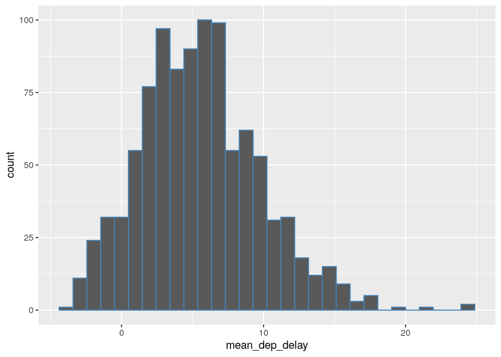

```r
ggplot(data = summary_mean_dist, mapping = aes(x = mean_dep_delay)) +
  geom_histogram(color = "steelblue")
```

What is the *standard error* of this distribution?

```r
summary_std <- summary_mean_dist %>%
  summarize(sd_dep_delay = sd(mean_dep_delay))
summary_std
```

```
## # A tibble: 1 × 1
##   sd_dep_delay
##          <dbl>
## 1         4.21
```

## What happens if we used a bigger sample?

What if we had picked 100 flights per sample, instead of 50? This is like using a bigger shovel in the in-class example. Repeat your work above to create a new sampling distribution (again, with 1000 samples). Again you'll want to visualize it as a histogram, too.

```r
bigger_sample_alaska_flights_dist <- alaska_flights %>%
  rep_sample_n(size = 100, reps = 1000)
bigger_sample_alaska_flights_dist
```

```
## # A tibble: 100,000 × 20
## # Groups:   replicate [1,000]
##    replicate  year month   day dep_time sched_…¹ dep_d…² arr_t…³ sched…⁴ arr_d…⁵
##        <int> <int> <int> <int>    <int>    <int>   <dbl>   <int>   <int>   <dbl>
##  1         1  2013     3     8     1012      725     167    1348    1030     198
##  2         1  2013     3    15     1818     1820      -2    2144    2135       9
##  3         1  2013     4    19      724      725      -1     958    1015     -17
##  4         1  2013     3     6      718      725      -7    1009    1030     -21
##  5         1  2013     1    18     1811     1815      -4    2155    2130      25
##  6         1  2013    12     2      700      705      -5     930    1017     -47
##  7         1  2013     9     9      721      720       1     956    1025     -29
##  8         1  2013     4    15      718      725      -7     958    1015     -17
##  9         1  2013     3    28      717      725      -8    1004    1030     -26
## 10         1  2013     3    20     1817     1820      -3    2104    2135     -31
## # … with 99,990 more rows, 10 more variables: carrier <chr>, flight <int>,
## #   tailnum <chr>, origin <chr>, dest <chr>, air_time <dbl>, distance <dbl>,
## #   hour <dbl>, minute <dbl>, time_hour <dttm>, and abbreviated variable names
## #   ¹sched_dep_time, ²dep_delay, ³arr_time, ⁴sched_arr_time, ⁵arr_delay
## # ℹ Use `print(n = ...)` to see more rows, and `colnames()` to see all variable names
```

```r
bigger_sample_summary <- bigger_sample_alaska_flights_dist %>%
  group_by(replicate) %>%
  summarize(mean_dep_delay = mean(dep_delay))
bigger_sample_summary
```

```
## # A tibble: 1,000 × 2
##    replicate mean_dep_delay
##        <int>          <dbl>
##  1         1           8.76
##  2         2           8.52
##  3         3           1.3
##  4         4           3.77
##  5         5          10.1
##  6         6           1.74
##  7         7           4.44
##  8         8           7.63
##  9         9           3.86
## 10        10           1.85
## # … with 990 more rows
## # ℹ Use `print(n = ...)` to see more rows
```

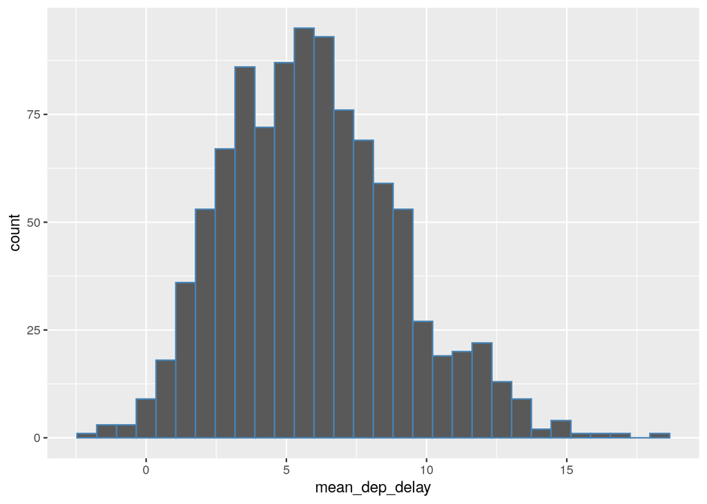

```r
ggplot(data = bigger_sample_summary, mapping = aes(x = mean_dep_delay)) +
  geom_histogram(color = "steelblue")
```

How did the distribution change when we increased the sample size to 100?

```r
bigger_summary_std <- bigger_sample_summary %>%
  summarize(sd_dep_delay = sd(mean_dep_delay))
bigger_summary_std
```

```
## # A tibble: 1 × 1
##   sd_dep_delay
##          <dbl>
## 1         3.09
```

## Check your intuition

### Terms you should know

You don't have to do anything here, but make sure you can define the following concepts. Practice identifying what they refer to in the textbook example and in the example we've done in this worksheet.

- Population
- Sample
- Population statistic
- Sample statistic
- Sample variability
- Sampling distribution
- Standard error